# PEC1 Análisis de Datos ómicos

Efecto del ácido araquidónico sobre las células cancerosas de próstata

Angellys Correa Marañon

# 1 Introducción

El estudio seleccionado es sobre el efecto del ácido araquidónico sobre las células cancerosas de próstata PC-3 incubadas con ácido araquidónico (AA), el cual es un ácido graso omega-6 que induce la proliferación de células cancerosas.

# 2 Objetivos

- Utilizar Bioconductor para el análisis y visualización de datos ómicos por medio del lenguaje de programación R.
- Obtener un expressionSet de los datos de un estudio utilizando el paquete GEOquery.
- Realizar un estudio exploratorio univariante y multivariante con los datos descargados.

# 3 Métodos

El presente análisis corresponde a la información de un dataset de GEO (Gene Expression Omnibus) seleccionado de la lista del documento GEOdatasetsUpdatedNov2022.xls, que contiene una lista de registros de GEO.

```r
library(readxl)
GEOdat <- read_excel("GEOdatasets_updatedNov2022.xls")
head(GEOdat)
```

```
## # A tibble: 6 × 4
##   `GEO Dataset` `GEO Serie` Especie           Título
##   <chr>         <chr>       <chr>             <chr>
## 1 GDS1251       GSE2401     Rattus norvegicus Acute hypotension effect on kidne…
## 2 GDS1736       GSE3737     Homo sapiens      Arachidonic acid effect on prosta…
## 3 GDS2107       GSE3311     Rattus norvegicus Long-term ethanol consumption eff…
## 4 GDS2153       GSE5370     Homo sapiens      Dermatomyositis
## 5 GDS2294       GSE5583     Mus musculus      Histone deacetylase 1 deficient e…
## 6 GDS2300       GSE5668     Mus musculus      Germinal vesicle stage and metaph…
```

Para obtener los datos se puede utilizar los identificadores “Dataset” y “Serie”. Es este caso, selecciono la Serie GSE3737, correspondiente a un estudio sobre el efecto del ácido araquidónico sobre las células cancerosas de próstata. Los datos se leen y descargan desde GEO.

```r
library(GEOquery)
gse <- getGEO("GSE3737", GSEMatrix = TRUE)
```

Se determina la estructura y diseño del estudio:

```r
class(gse)
```

```
## [1] "list"
```

```r
length(gse)
```

```
## [1] 1
```

```r
gse[[1]]
```

```
## ExpressionSet (storageMode: lockedEnvironment)
## assayData: 22283 features, 8 samples
##   element names: exprs
## protocolData: none
## phenoData
##   sampleNames: GSM86079 GSM86080 ... GSM86086 (8 total)
##   varLabels: title geo_accession ... data_row_count (30 total)
##   varMetadata: labelDescription
## featureData
##   featureNames: 1007_s_at 1053_at ... AFFX-TrpnX-M_at (22283 total)
##   fvarLabels: ID GB_ACC ... Gene Ontology Molecular Function (16 total)
##   fvarMetadata: Column Description labelDescription
## experimentData: use 'experimentData(object)'
##   pubMedIds: 16452198
## Annotation: GPL96
```

Viasualizamos en ExpressionSet de Los datos se extraen de la lista que los contiene en forma de objeto de clase ExpressionSet, además de visualizar la matriz de expresión y las covariables, econtrando que el conjunto de datos de la expresión génica GSE3737 contiene 8 identificadores de muestras con 22283 características y 30 variables:

```r
myEset <- gse[[1]]
class(myEset)
```

```
## [1] "ExpressionSet"
## attr(,"package")
## [1] "Biobase"
```

```r
head(exprs(myEset))
```

```
##           GSM86079 GSM86080 GSM86081 GSM86082 GSM86083 GSM86084 GSM86085
## 1007_s_at    738.9    620.1    706.6    985.2    664.3    557.2    991.6
## 1053_at       96.1    312.8    129.9    341.1    109.1    143.4    420.5
## 117_at       100.8     83.1     83.5    245.5    102.3     66.2    161.5
## 121_at       823.4    646.2    805.9   1122.7    635.1    598.1    991.9
## 1255_g_at     38.3     23.2     13.0     51.3     29.9     23.7     47.9
## 1294_at      239.7    100.6    180.3    198.9    249.8    150.6    106.0
##           GSM86086
## 1007_s_at    873.5
## 1053_at      439.2
## 117_at       185.2
## 121_at       809.9
## 1255_g_at     56.9
## 1294_at       90.7
```

```r
colnames(pData(myEset))
```

```
##  [1] "title"                   "geo_accession"
##  [3] "status"                  "submission_date"
##  [5] "last_update_date"        "type"
##  [7] "channel_count"           "source_name_ch1"
##  [9] "organism_ch1"            "characteristics_ch1"
## [11] "molecule_ch1"            "label_ch1"
## [13] "taxid_ch1"               "description"
## [15] "data_processing"         "platform_id"
## [17] "contact_name"            "contact_email"
## [19] "contact_phone"           "contact_laboratory"
## [21] "contact_department"      "contact_institute"
## [23] "contact_address"         "contact_city"
## [25] "contact_state"           "contact_zip/postal_code"
## [27] "contact_country"         "supplementary_file"
## [29] "supplementary_file.1"    "data_row_count"
```

# 4 Resultados: Análisis exploratorio de datos

A continuación se presenta una primera visión o resumen básico estadístico del dataset y la representación de las muestras en histogramas y diagramas de cajas.

```r
round(apply(myEset,2, summary))
```

```
##         GSM86079 GSM86080 GSM86081 GSM86082 GSM86083 GSM86084 GSM86085 GSM86086
## Min.           0        0        0        0        0        0        0        0
## 1st Qu.       28       24       28       46       25       25       41       37
## Median        98       89       97      174       91       89      164      151
## Mean         368      356      353      772      359      382      700      703
## 3rd Qu.      289      283      291      552      289      285      568      554
## Max.       21604    13463    16852    39899    16379    29873    26968    25612
```

```r
library(ggplot2)
```

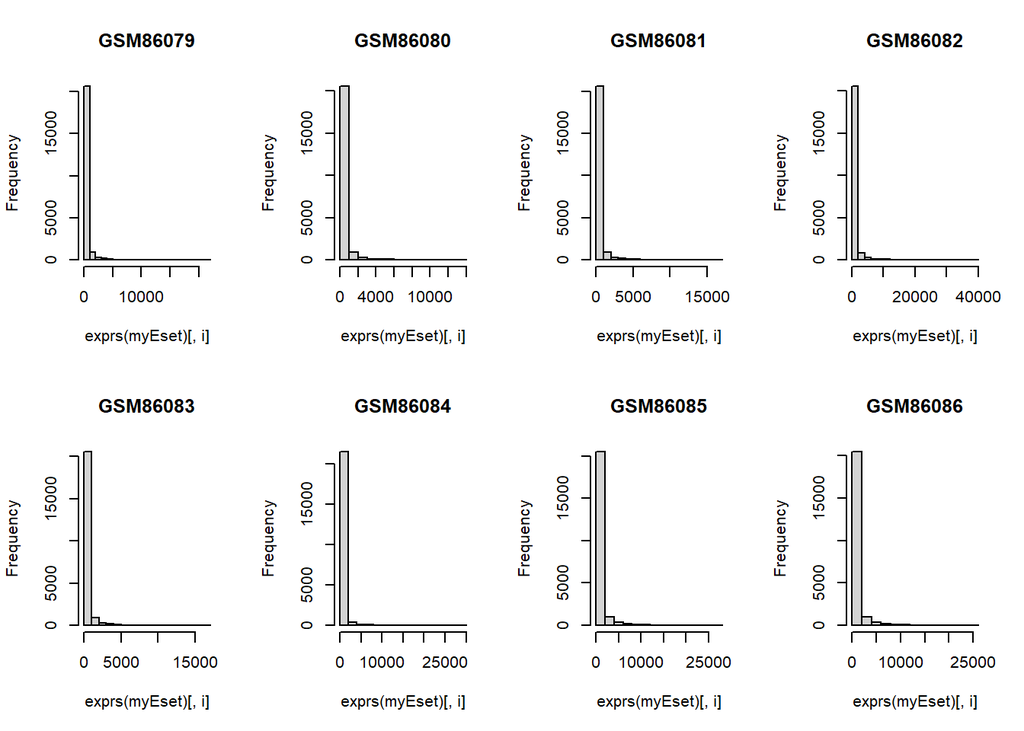

```r
cap <- par(mfrow=c(2,4))
for (i in 1:ncol(exprs(myEset))) {
  hist(exprs(myEset)[,i], main = colnames(exprs(myEset))[i])
}
```

```r
par(cap)
```

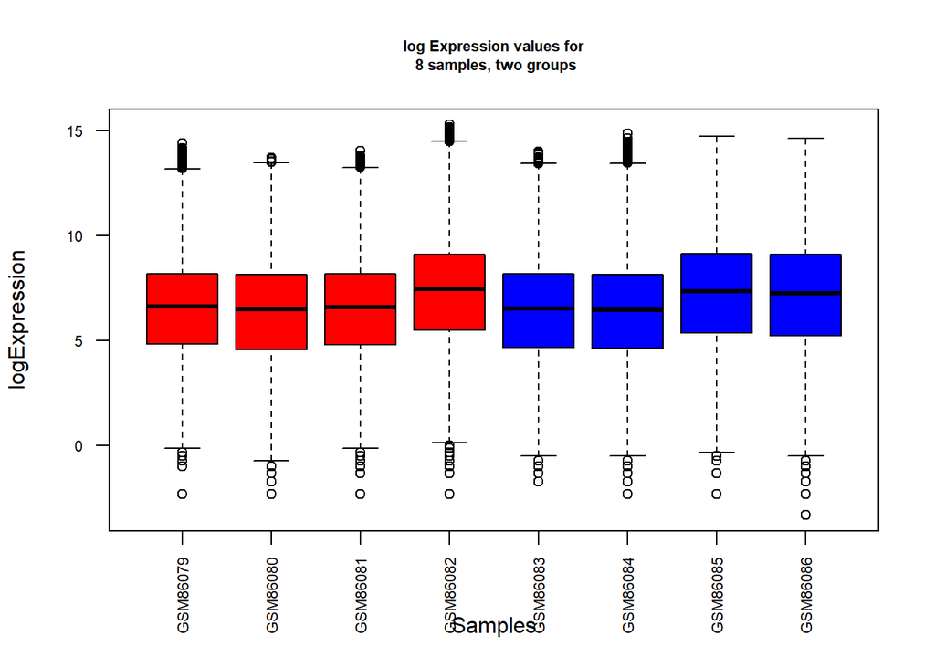

```r
logX <- log2(exprs(myEset))
groupColors <- c(rep("red", 4), rep("blue", 4))
boxplot(logX, col=groupColors, main="log Expression values for\n 8 samples, two groups",
    xlab="Samples",
    ylab="logExpression", las=2, cex.axis=0.7, cex.main=0.7)
```

# 5 Apéndices

Código completo:

library(readxl)

GEOdat <- read_excel(“GEOdatasets_updatedNov2022.xls”)

head(GEOdat)

library(GEOquery)

gse <- getGEO(“GSE3737”, GSEMatrix = TRUE)

class(gse)

length(gse)

gse[[1]]

myEset <- gse[[1]]

class(myEset)

head(exprs(myEset))

colnames(pData(myEset))

round(apply(myEset,2, summary))

library(ggplot2)

cap <- par(mfrow=c(2,4)) for (i in 1:ncol(exprs(myEset))) { hist(exprs(myEset)[,i], main = colnames(exprs(myEset))[i]) } par(cap)

logX <- log2(exprs(myEset)) groupColors <- c(rep(“red”, 4), rep(“blue”, 4)) boxplot(logX, col=groupColors, main=“log Expression values for samples, two groups”, xlab=“Samples”, ylab=“logExpression”, las=2, cex.axis=0.7, cex.main=0.7)